# GAMES-2025-0051

Converted from PDF `Ma-VideoGameLayoffCrisis-2025-ACMGames.pdf` · 27 pages · anchors: page `#pN`, block `#pN-bK`

Page 1

### **From the Atari Shock to a Modern Crisis: Analyzing Mass Layoffs in the Post-Pandemic U.S. Video Game Industry**

JIESI MA , Washington University in St Louis, St. Louis, United States

Since 2023, the video game industry (VGI) has faced a severe workforce reduction marked by widespread layoffs, studio closures, and project cancellations, with the United States being the most affected nation. This study employs comparative analysis to investigate the underlying drivers of this layoff crisis, drawing parallels with the 1983 Video Game Crash (Atari Shock) to identify historical commonalities and contem- porary divergences. Using a three-level framework, it analyzes macroeconomic shifts (e.g., monetary policy changes), industry dynamics (e.g., management inefficiencies, rising costs), and project-level risks (e.g., failed live-service transitions, imitative design) to interpret systemic vulnerabilities through established theories in business studies, project management, and game development. Notably, the industry’s resilience—rooted in globalized production networks and diversified revenue streams—has averted systemic collapse, instead containing the crisis as a supply-side turbulence.

CCS Concepts: • **Social and professional topics** →**Employment issues** ;

Additional Key Words and Phrases: Video game industry, video game history, layoffs, video game development, monetary policies, corporate management, project management

**ACM Reference Format:** Jiesi Ma. 2025. From the Atari Shock to a Modern Crisis: Analyzing Mass Layoffs in the Post-Pandemic U.S. Video Game Industry. *ACM Games* 4, 1, Article 2 (December 2025), 27 pages. https://doi.org/10.1145/3774758

#### **1 Introduction**

After decades of development, the **video game industry** ( **VGI** ) has become a global industry [ 1 ], providing hundreds of thousands of direct and indirect job opportunities worldwide. However, since late 2022, VGI has faced major workforce cuts, with mass layoffs and studio closures posing profound challenges [ 2 ]. During this period, widespread project cancellations and organizational downsizing led to 10,500 job losses in 2023, 14,600 in 2024, and a continuing trend in 2025 [ 3 ]. Notably, every week of 2024 saw layoffs or business closures, disproportionately impacting North America and Europe—with the U.S. most affected [ 4 ]. The **Game Developer Conference** ( **GDC** ) 2025 report notes 11% of developers experienced layoffs in the prior year. Corporations cite re- structuring, declining revenue, and market shifts as reasons, while developers attribute layoffs to COVID-19 effects, corporate greed, and previous over-hiring [ 5 ].

The author received no financial support for the research, authorship, and/or publication of this article. Author’s Contact Information: Jiesi Ma, Washington University in St Louis, St. Louis, Missouri, United States; e-mail: arcboundavenger@gmail.com.

This work is licensed under a Creative Commons Attribution-NonCommercial-NoDerivs 4.0 International License.

© 2025 Copyright held by the owner/author(s). ACM 2832-5516/2025/12-ART2 https://doi.org/10.1145/3774758

Page 2

The VGI’s ongoing employment downturn is causing widespread workforce reductions and project cancellations, forcing many companies to reorganize. However, current literature lacks comprehensive analysis of this event, highlighting this study’s necessity. This study focuses pri- marily on the impacted U.S. VGI—specifically examining publicly traded entities and their sub- sidiaries, alongside startups and mid-sized companies primarily backed by **private equity** ( **PE** ) or **venture capital** ( **VC** ) funding, which have disclosed the most extensive layoff data. This segment includes global giants like Microsoft Gaming, Sony Interactive Entertainment, and Electronic Arts, plus most U.S.-based mid-sized video game companies. While small and independent studios now employ comparable numbers to large firms [ 8 ], mid-to-large sized video game companies are still widely recognized as the essential part of VGI that drives industry practices [ 9 ]. Moreover, limited public data on workforce reductions at independent teams places this segment outside the core scope of this study.

As the first systematic investigation of mass layoffs in the U.S. VGI, this study seeks to examine the underlying drivers of the ongoing industry crisis. By conducting a comparative analysis with the Video Game Crash of 1983—a major collapse event in gaming history—this study aims to illuminate both historical parallels and contemporary distinctiveness in their underlying mecha- nisms. The findings offer a historically grounded understanding of recent mass layoffs and provide actionable strategies for industry stakeholders to navigate the current crisis challenges effectively. This dual-temporal approach contributes meaningful perspectives to academic discourse on VGI dynamics while supporting long-term industry sustainability.

**2 Research Questions** This study investigates the following interconnected questions, examining the phenomenon of massive layoffs within the U.S. VGI through both historical and contemporary lenses:

• What potential factors contributed to the mass layoffs across U.S. VGI following the COVID-19 pandemic? • How do the mechanisms driving post-pandemic workforce reductions compare to those during the Video Game Crash of 1983? • What actionable strategies can developers employ to enhance resilience?

By addressing these questions, this research aims to provide a holistic and historically grounded understanding of the recent waves of layoffs in the U.S. VGI. The findings seek to yield insights pertinent to the present industry context while contributing meaningful perspectives to the aca- demic discourse on VGI dynamics.

#### **3 Background and Context**

It is well known that the video games originated in the U.S. [ 10 ]. The origin of U.S. VGI was intrinsically linked to the 1950s–1960s nascent U.S. computer industry, drawing talent from early computer hardware ecosystem around **Massachusetts Institute of Technology** ( **MIT** ) and Sili- con Valley [ 11 ]. MIT graduate Steve Russell programmed one of the earliest games, *Spacewar!* , on a PDP-1 computer in 1962 [ 12 ]. In 1972, Nolan Bushnell founded Atari, which earned traction with *Pong* [ 13 ]. In 1977, Atari achieved dominance in the U.S. home console market with the success of its Atari 2600 [ 14 ].

Until 1979, Atari retained exclusive software development rights for its Atari 2600. Although maintained dominance in the late 1970s, Atari released numerous overhyped yet poorly designed games, such as *Superman* [ 15 ], due to mismanagement. Then, four engineers upset at their treatment by Atari left to form Activision. Atari initially threatened legal action but eventually adopted a royalty system for third-party developers. This shift led to a sharp rise in third-party

Page 3

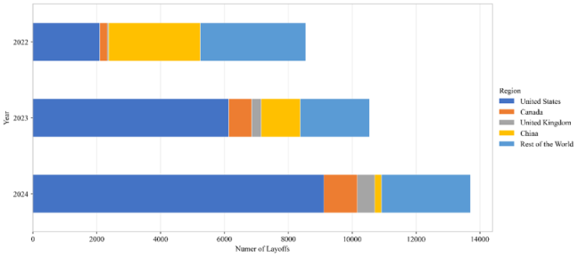

NOTE: figure/graphic rendered as an image from the PDF; its content is not machine-readable text. Caption (if any) follows as the next block.

Fig. 1. Gaming industry layoffs by country, 2022–2024. *Source* : Adapted from Gaming Industry Layoffs tracker [ 6 ]. *Note* : Layoffs in China in 2022 were driven by a temporary pause in game licensing approvals, followed by a rapid recovery as approvals resumed [ 7 ].

game developers, fueled by VC [ 16 ]. By 1982, the U.S. VGI had expanded into a multi-billion-dollar market, with over 150 third-party developers having released games for the Atari 2600 [ 16 ]. Lowered barriers enabled even non-gaming entrants like Quaker Oats to release many poorly received titles [ 17 ]. Fierce competition and talent shortages caused rampant game replication. Atari 2600 ROM analysis shows declining lexical diversity and information complexity amid increasing releases [ 18 ]. By 1983, imitators outnumbered expert developers 4:1, leaving most games homogeneous. The flood of inexperienced and underfunded developers caused a glut in the video game market [ 19 ]. However, due to their small size, lack of knowledge, limited resources, and weak market presence, these new entrants were particularly vulnerable [ 20 ]. Eventually, combined with a market flooded with low-quality game clones and tightening monetary policies in the U.S. [ 21 ], the commercial failure of *E.T. the Extra-Terrestrial* triggered the Video Game Crash of 1983 [ 22 ], an industry-wide collapse that plunged the U.S. VGI into severe recession.

The U.S. video game market’s decline finally reversed with the launch of **Nintendo Entertainment System** ( **NES** ) in U.S. in 1985 [ 28 ], which initiated the U.S. VGI’s gradual recovery through rigorous quality control. After the Atari Shock, many developers shifted from console to PC game development, with 1982-founded Electronic Arts among the influential companies established in this period. As PCs gained widespread adoption in the 1980s, two parallel gaming markets emerged in the U.S.: PC gaming and console gaming [ 29 ].

In the 1990s, hardware and software advances drove rapid VGI transformation. Key milestones, such as Microsoft’s Windows 95/DirectX (1995) and NVIDIA’s GeForce 256 (1999) redefined the PC gaming infrastructure. Microsoft’s 2001 Xbox launch subsequently established it as a major

Page 4

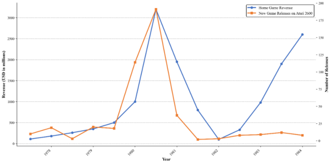

NOTE: figure/graphic rendered as an image from the PDF; its content is not machine-readable text. Caption (if any) follows as the next block.

Fig. 2. U.S. home game annual revenue (millions of dollars, inflation adjusted to 1983) and number of new game releases on Atari 2600. *Source* : Adapted from Ernkvist [ 16 ] and MobyGames [ 23 ]. *Note* : While the accuracy of specific data points may be subject to uncertainty, the overall trend is likely representative.

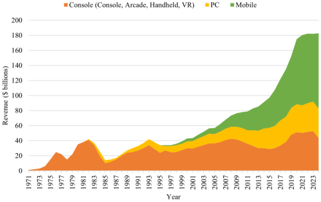

NOTE: figure/graphic rendered as an image from the PDF; its content is not machine-readable text. Caption (if any) follows as the next block.

Fig. 3. Global VGI revenue from 1970 to 2024. *Source* : Adapted from Bloomberg [ 26 ] and Newzoo [ 27 ].

console player yet around the same time, PC gaming began declining relative to consoles due to piracy enabled by expanded Internet access. However, the PC market downturn was reversed by Valve’s digital distribution platform Steam [ 30 ], which fundamentally transformed the business and distribution model of PC games: digital sales accounted for less than 50% of PC game sales in 2010 but rose to over 90% by 2013 [ 31 ].

Page 5

The 2007 iPhone launch was a major turning point, greatly expanding global Internet access and the player base via mobile. Capitalizing on this reach and the **free-to-play** ( **F2P** ) model’s low barrier to entry, smartphones grew to dominate global gaming revenue over the 2010s [ 32 ]. Simultaneously, globalization of VGI accelerated, enabling countries like Poland, China, and South Korea to narrow the gap in game development with traditional hubs like the U.S. and Japan. When it comes to mobile gaming, while companies like Zynga and Scopely have achieved success, no U.S. mobile game developer achieved dominance in the mobile sector comparable to the strong position U.S. companies hold in PC and console gaming.

#### **4 Methodology**

Over the past decades, scholars have proposed different explanations for the Atari Shock. A study by Ernkvist proposes a key framework called the “3Ds” model [ 16 ]. This analytical framework attributes the systemic failure to: (1) *Declining entry barriers* that caused market saturation; (2) *Decreasing product differentiation* in the market; (3) *Disruptive innovations* that obsoleted incum- bent firms’ core competencies. This model explains how these factors combined to bring about the Video Game Crash of 1983 and will also be adopted in this study.

Through comparative analysis [ 33 ], this study investigates the causes of the current layoff crisis by comparing it with the historical Atari Shock. Drawing on media sources, published histories of early VGI, and academic analyses, it centers on the business aspects of VGI. Additionally, while the “3Ds” framework explains the Atari Shock’s primary causes, it overlooks the economic context in which early 1980s game projects operated at a significantly smaller scale. Therefore, analyzing modern phenomena like post-COVID layoffs requires expanding the “3Ds” framework through economic, project management and game development lenses. This study analyzes the current crisis using a three-level framework: Macro (economic conditions), Meso (industry dynamics), and Micro (game development practices). Key factors within each level are interpreted using these dis- ciplinary perspectives. The discussion compares factors by consolidating findings from the current crisis analysis with literature-defined 1983 crash factors, identifying critical convergences and di- vergences.

#### **5 Macro-Level: Economic Conditions**

In the 2010s, the VGI underwent a decade of rapid growth. This led industry practitioners and observers to become accustomed to the growth, frequently overlooking the impact of macroe- conomic factors on the sector. Yet history provides warnings: As Figure 3 indicates, PC/console sectors endured a three-year downturn following the 2008 Great Recession [ 32 ]. Going further back, an often-overlooked fact is that the Atari Shock was also associated with the global reces- sion of 1982 [ 21 ]. These historical contractions clearly reveal the VGI’s vulnerability to macroeco- nomic trends. Similarly, the VGI’s growth during the COVID pandemic stemmed from converging macroeconomic forces—including expansive monetary policies and surging consumer demand— yet this growth trajectory reversed quickly after the macroeconomic conditions shifted. Analysis of this boom-and-bust cycle from 2020 to 2025 contextualizes recent mass layoffs and reveals pat- terns that may help mitigate future crises.

**5.1 The Impact of Monetary Policies** The U.S., home to the world’s most developed capital market [ 34 ], sees industries shaped by its cap- ital flows and ripple effects. Like other sectors, the VGI was deeply affected by COVID-19 and the concurrent monetary policies, with major advanced-economy central banks implementing **quan- titative easing** ( **QE** ) from 2020–2022 to counter the pandemic’s economic disruptions [ 35 ]. This expansionary policy empirically demonstrated to accelerate capital deployment in investments

Page 6

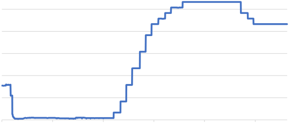

NOTE: figure/graphic rendered as an image from the PDF; its content is not machine-readable text. Caption (if any) follows as the next block.

Fig. 4. Federal funds effective rate, 2020–2025. *Source* : adapted from federal reserve economic data [ 49 ].

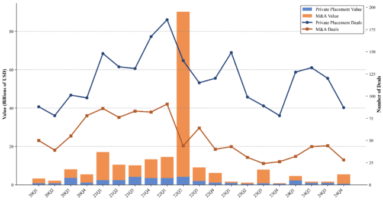

NOTE: figure/graphic rendered as an image from the PDF; its content is not machine-readable text. Caption (if any) follows as the next block.

Fig. 5. Gaming investment value and deals count, 2020–2024. *Source* : Adapted from InvestGame’s Global Gaming Deals Report [ 50 ].

[ 36 ]. Accordingly, publicly traded gaming corporations saw huge share price appreciation throughout 2020. Lockdowns made gaming a primary global entertainment source concurrently [ 37 ]. During this period, Steam’s peak concurrent online user count increased from 18.33 million in January 2020 to 29.20 million in January 2022 [ 38 ]. Newzoo reports that VGI revenue grew by 24.7% year-on-year, from $139.0 billion in 2019 to $173.4 billion in 2020 [ 27 ]. These demand-side dynamics interacted with QE-induced liquidity, creating a synergistic market environment.

Page 7

Although VC and PE are generally not the preferred financing source for game developers— previous research indicates game developers tend to favor publishers or outsourcing work for funding [ 51 ]—the U.S. VGI presents an exception. Due to its deep historical ties to the tech indus- try and the well-developed VC ecosystem, startup companies in the U.S. VGI more used to seeking through equity investments from VCs [ 52 ]. As shown in Figure 5 , this rise in liquidity and his- torically low interest rates also facilitated VC investments and led to the overvaluation of startup companies, catalyzing the formation of bubbles [ 53 ]. Notably, despite performing well during fi- nancial downturns, PE tends to underperform when both the stock market and enterprise values are already high due to cyclicality and liquidity risks [ 54 ].

This financial environment led to widespread over-hiring practices not only in the technology industry but also in the gaming sectors. Federal Reserve Economic Data reveals that software de- velopment job postings on Indeed in the U.S. doubled from their early-2020 levels by mid-2022 (see Figure 6 ) [ 55 ]. To counter productivity losses from remote work [ 56 ], capital-flush major corpora- tions deployed aggressive acquisitions and workforce expansions, while VC-backed startups also competed for talent. Consequently, over-hiring in U.S. VGI became pronounced.

The VGI from 2020 to 2022 displayed a thriving landscape, with industry seemingly more optimistic about the future of gaming than ever before. S&P once estimated that the global gaming market’s revenue could grow to $200 billion in 2022 [ 57 ]. However, the growth trajectory reversed sharply starting in 2022, coinciding with the Federal Reserve’s initiation of interest rate increase- ment [ 58 ]. These rate hikes triggered a sharp contraction in market liquidity and increased fi- nancing costs across the economy [ 59 ], putting immense pressure on game developers. By the first quarter of 2023, quarterly investment inflows into the VGI sector had declined precipitously, marking a dramatic contraction compared with the preceding boom [ 60 ].

#### **5.2 Stagnation of Player Growth**

The mobile Internet boom of the 2010s triggered player population expansion, a trend amplified by COVID-19 lockdowns. This expansion resulted in global players increasing from 1.99 billion in 2015 to 3.42 billion in 2024 [ 61 ], yet the growth rate declined from over 10% in 2021 to under 2% in 2024 – reaching their lowest level in a decade (see Figure 7 ). Furthermore, most player growth came from emerging regions with limited purchasing power [ 62 ].

Concurrently, liquidity contraction stemming from tight monetary policy also impacted the demand side. In 2024, global gaming revenue experienced an annualized growth of only 0.5%, with North America—the region most severely affected by layoffs—recording a minimal annual- ized growth rate of 0.1% [ 27 ]. This sustained low-growth trend not only reflects the short-term

Page 8

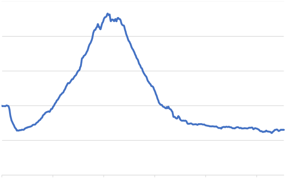

NOTE: figure/graphic rendered as an image from the PDF; its content is not machine-readable text. Caption (if any) follows as the next block.

Fig. 6. Software development job postings on indeed in the U.S., 2020–2024. *Source* : adapted from federal reserve economic data [ 55 ].

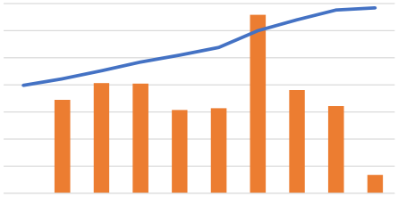

NOTE: figure/graphic rendered as an image from the PDF; its content is not machine-readable text. Caption (if any) follows as the next block.

Fig. 7. Global player count and growth rate (2015–2024). *Source* : adapted from Newzoo [ 63 ].

pressure from demand-side constraints amid monetary tightening but also aligns with broader industr y obser vations. Based on such data, Newzoo concludes that the global PC and mobile game markets have reached maturity, with limited growth potential in 2025.

**6 Meso-Level: Industry Dynamics** The wave of M&A among major gaming companies from 2020 to 2022 significantly increased mar- ket concentration in the U.S. VGI. This trend was anticipated by Winseck and Yong Jin, who earlier

Page 9

identified a “oligopolistic core” of large corporations dominating the VGI, surrounded by smaller firms [ 64 ]. A decade ago, numerous independent AAA studios—including Obsidian Entertainment, Bungie, Insomniac Games, Respawn Entertainment, and Gearbox Software—remained active in the U.S. Yet, nearly all were acquired during the COVID-19 M&A wave, markedly strengthening oligopolistic tendencies in the U.S. market.

The potential negative impacts of oligopoly on the industry are frequently discussed in literature, such as reduced consumer welfare [ 65 ], diminished product quality [ 66 ], and suppressed innovation [ 67 ]. These trends are already observable in the video game market: despite strong opposition from players, major game companies have decided to raise the standard price of AAA games from $60 in 2020 to $80 in 2025 [ 68 ], a 33.3% hike, while the revenue growth of the global VGI during the same period was only 2.5%. Meanwhile, game quality from leading firms showed little improvement, with many flagship products receiving broadly negative reviews from critics and users alike (e.g., References [ 69 –71 ]).

**6.1 Rising Costs and Risks** The traditional video game production model carries high risks for investors and developers, as it demands substantial time and capital upfront, while market reception remains uncertain until after release. Investors are exposed to liquidity and market risks [ 72 ], while developers face significant tech and cost risks [ 73 ].

Meanwhile, modern game development faces significantly increased financial risks due to exponentially rising production costs [ 74 ], driven by extended development cycles and team expansion. To meet growing player expectations for performance, narrative, and graphics [ 75 ], teams have expanded to include diverse roles such as design, programming, art, sound, management, and quality assurance [ 76 ]. However, as developers expand their team size, efficiency and productivity do not maintain a linear positive correlation [ 77 ]. This phenomenon, commonly termed Brooks’ Law in software project management [ 78 ], stems from multiple factors. While initial expansion may benefit from labor specialization [ 79 ], exceeding the optimal team size raises management difficulties [ 80 ]. The growth in communication channels escalates coordination costs [ 81 ], and documentation volume increases disproportionately. Furthermore, necessary sharing of critical assets between departments often triggers interdepartmental conflicts in large corporations [ 82 ]. These compounding factors collectively contribute to diseconomies of scale in development [ 83 ], ultimately diminishing team productivity and compromising game quality.

Over the decades, the development timelines of video games have been substantially increased (see Figure 8 ). Release intervals have likewise expanded: Between 2009 and 2015, Naughty Dog consistently put out a new game every two years. Yet after *Uncharted 4* (2015), players waited five years for their next title, *The Last of Us Part II* (2020), and their next game is reported to be released no earlier than 2027. Other U.S.-based AAA studios like Bethesda and Gearbox Software show similar patterns. This temporal expansion, combined with organizational scaling, creates a dual cost multiplier, propelling development costs to unprecedented heights.

For AAA games, marketing expenses that commensurate with development costs significantly increase the total budget. Current AAA games budgets routinely exceed $100 million, with flagship titles like *Call of Duty: Black Ops Cold War* reportedly approaching $700 million in development costs [ 86 ]. Since 2020, game development costs in the U.S. have reached the world’s highest levels, with per-developer expenditures typically doubling or tripling those in Eastern Europe and China [ 87 ]. These soaring costs were manageable during industry expansion but became unsustainable amid revenue stagnation or decline. Public financials reflect the impact: EA’s net income declined after 2021 [ 88 ], while Take-Two’s similarly fell following its acquisition of Zynga in 2022 and turned negative [ 89 ]. Escalating costs eroded large corporations’ financials while burdening

Page 10

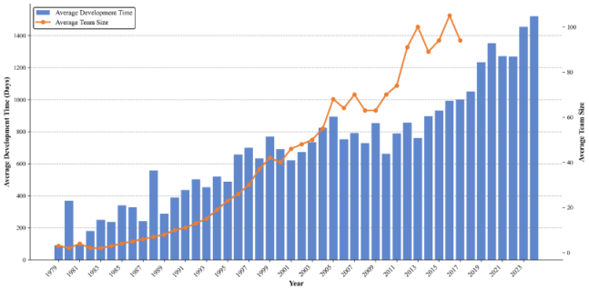

NOTE: figure/graphic rendered as an image from the PDF; its content is not machine-readable text. Caption (if any) follows as the next block.

Fig. 8. Average development time and team size for video game projects over time. *Source* : Development time data adapted from SpriteCell [ 84 ]; team size data adapted from Mobygames via World Intellectual Property Organization [ 85 ]. *Note* : Development time records were manually extracted by SpriteCell from primary sources (developer interviews, official documents, and retrospective publications).

medium enterprises, and U.S. video game companies of all sizes resorted to layoffs to reduce expenses.

#### **6.2 Corporate Management Challenges**

For major gaming corporations in an industry boom, both investment decision and postinvestment management present multifaceted challenges. According to agency cost theory [ 90 ], key motives for excessive investment activities in large corporations include empire-building [ 91 ], tunneling [ 92 ], or even personal preference [ 93 ]. Driven by private benefits [ 94 ], influential man- agers in such corporations may invest in **negative net present value** ( **NPV** ) projects or pet projects [ 92 ], both at the expense of shareholder interests. Research also indicates that managerial overconfidence can lead executives to overestimate investment returns, thereby distorting corpo- rate investment decisions [ 95 ]. While significantly expanding the size of corporation, these invest- ments and mergers do not necessarily enhance its profitability or enterprise value [ 96 ].

Post-M&A corporate integration has also been widely studied, with many studies attributing poor post-acquisition performance to inadequate governance and integration. Overall, factors in- fluencing post-M&A performance are complex, including planning and execution of integration [ 97 ], resolution of managerial conflicts of interest [ 98 ], establishment of suitable reward systems [ 99 ], clarification of corporate vision, and cultivation of a unified organizational culture [ 100 ].

Examining M&A cases within the VGI during 2020–22 reveals that many underperformers were directly linked to post-acquisition integration failures (e.g., [ 101 , 102 ]). For VC-backed small to medium-sized studios, the challenges manifest differently. The highly modular and specialized labor structure required in the game production process compounds these challenges for new ventures [ 103 ]. These companies must navigate a range of issues during development, such as controlling cost and quality [ 104 ]; managing risk [ 73 ]; and handling human capital management [ 105 ]. Startups typically lack resources to address modern VGI’s specialized complexity, while VCs often lack technical expertise to effectively tackle these challenges. Escalating investment manage- ment complexity causes unresolved issues to accumulate, leading to underperforming projects and

Page 11

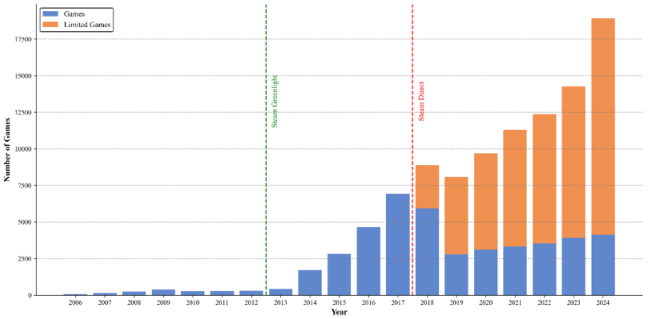

NOTE: figure/graphic rendered as an image from the PDF; its content is not machine-readable text. Caption (if any) follows as the next block.

Fig. 9. The number of games released on Steam each year. *Source* : Adapted from SteamDB [ 38 ]

subsequent layoffs and studio closures. This phenomenon emerged during the Atari Shock era and has now resurfaced in the post-pandemic VGI after the investment boom.

**6.3 Hypercompetitive Crowded Markets** The contemporary gaming market faces fierce supply-side competition, particularly evident in platform distribution dynamics. On Steam, the world’s largest digital game distribution platform [ 106 ], the annual number of new game releases serves as a direct indicator of the intensifying supply-side competition in the VGI.

In 2017, Steam replaced its community-driven Greenlight system with Steam Direct, which allows anyone to publish a game [ 107 ]. This transition reduced Valve’s oversight of game quality and game supply skyrocketed (see Figure 9 ). A study revealed that while the number of players on Steam increased linearly, the number of games released grew exponentially [ 108 ].

This oversupply has precipitated a pronounced Matthew effect [ 109 ], with top-performing titles dominate most of the player base [ 110 ]. Third-party statistics further substantiate this phenom- enon. According to VGInsights data, 75% of paid games on the Steam platform generate lifetime revenues below $10,000, while the top 1% soar to $7 million [ 111 ]. Steam’s visibility algorithm, which prioritizes sales performance and wishlist accumulation [ 112 ], reinforces market concen- tration by promoting commercially successful titles. This creates a downward spiral where games which have weak launch performance face algorithmic demotion, further constraining their visi- bility and recovery potential. In the hyper-competitive environment after the COVID-19 pandemic, the number of games achieving profitability has become even scarcer.

#### **6.4 Shifting Player Behaviors**

Nowadays, the time players can allocate to gaming is increasingly squeezed by other entertainment forms, such as social media and online video platforms. This phenomenon aligns with attention economy theory [ 113 ], which posits that the abundance of information leads to a scarcity of at- tention. For instance, from 2020 to 2024, the time spent by U.S. adults on online video platforms (e.g., YouTube, Netflix, TikTok) increased by an average of 30% [ 114 ] Conversely, time spent play- ing video games decreased by 26% between 2021 and 2023 [ 115 ]. This imbalance between supply

Page 12

(video games and other entertainment forms) and demand (user attention) underscores the intensifying competition for limited cognitive resources.

Meanwhile, players continue to spend substantial time and funds to established games. Steam’s 2024 statistics revealed that only 15% of total playtime was attributed to games released that year [ 116 ]. Sales data further confirms this pattern: among Steam’s top 12 best-selling products of 2024, only four were new releases, while existing titles like *Counter-Strike 2, DOTA 2, PUBG* , A *pex Leg- ends* , and *Call of Duty* maintained top positions for three consecutive years [ 117 ]. This aligns with Newzoo’s finding in 2023 that just 66 titles accounted for 80% of all playtime hours across PC and consoles [ 115 ], highlighting a strong long-tail effect favoring enduring games.

In the mobile gaming sector, the introduction of Apple’s Identifier for Advertisers (IDFA) changes in Q1 2021 has led to the first decline in global mobile game revenue in history [ 118 ]. De- spite this, players still favor older titles: only one of 2024’s top 10 highest-grossing mobile games was released that year [ 119 ]. This pattern indicates that, across platforms, players invest time and money predominantly in older games, highlighting a strong lock-in effect [ 120 ], making it increas- ingly challenging for new games to gain traction in a competitive market.

#### **7 Micro-Level: Game Development Practices**

**7.1 Live Service Dilemma** In the 1980s, most games were designed for one-time experiences with limited replay value. How- ever, the rise of online games and microtransactions after 2000s has embedded the live service model into players’ consuming habits [ 121 ]. The 21st century introduced live service titles—such as *World of Warcraft* and *League of Legends* on PC, along with mobile successes like *Honor of Kings* and *Monster Strike* —that have remained popular for over a decade. Through ongoing updates and varied in-game purchase designs, this business model secures stable cash flows for video game companies [ 122 ]. By generating reliable revenue that provides resilience against market volatility, the live service approach, also known as **Games-as-a-Service** ( **GaaS** ) [ 123 ], has become vital to the modern video game business.

Although the transition from traditional premium AAA games toward GaaS models began to be explored by video game companies in the 2010s [ 124 ], it was not widely adopted due to the high expertise requirements for developers and the need for sophisticated data analytics infras- tructures. Leading companies like Sony and Microsoft continued to rely primarily on traditional AAA models in this period. However, in the 2020s, the increasing development cycles and costs of AAA games have inevitably led to gaps in release schedules and unstable cash flow for publishers. Even industry leaders like Microsoft experienced a notable gap, lacking first-party AAA releases for over 12 months since March 2022 [ 125 ]. Major corporations begun to perceive GaaS titles as both generators of steady long-term revenue streams and catalysts for strategic transformations, driving substantial acquisitions of such games/developers. For example, under Jim Ryan’s leader- ship, Sony Interactive Entertainment pivoted its strategy toward the GaaS model in 2022 [ 126 ]. At its peak, Sony had 12 live service games in development while acquiring studios like Bungie and Firewalk Studios specializing in GaaS development [ 127 ]. Similarly, Microsoft bolstered its portfolio through the Activision Blizzard acquisition, gaining long-running live-service franchises including *Call of Duty, World of Warcraft* and *Candy Crush Saga* [ 45 ].

While major companies acknowledge GaaS’s importance, transitioning from traditional AAA single-player games to a GaaS model remains challenging. This shift requires extensive user metric tracking and analysis [ 128 ], with ongoing calibration of in-game economies and mone- tization based on such data. However, most traditional AAA studios lack these capabilities due to fundamental differences in data paradigms: key live service metrics such as player retention and payer conversion are neither monitored nor relevant in single-player games. Other barriers

Page 13

include developers’ reluctance to adopt online models, inexperience in user operations, data analytics, and economy design, as well as limited agility in integrating feedback via continuous development—all critical for successful GaaS implementation [ 129 ]. Moreover, for companies that are new to GaaS models, conservative monetization designs may lead to games failing to break even, while greedy or pay-to-win **microtransaction** ( **MTX** ) designs may trigger severe player backlash and result in commercial failure [ 130 ]. Balancing monetization with player satisfaction requires extensive, ongoing testing and feedback integration. Many initiatives from traditional U.S. AAA and new studios have failed due to a lack of critical GaaS expertise.

#### **7.2 Imitative Strategies**

The VGI’s rising development costs, intensifying competition and escalating risks have led to what scholars term an “innovation dilemma” [ 131 ]. Though creativity is crucial for entertainment prod- ucts, the industry now faces shorter product life cycles, rapidly evolving technologies, and shift- ing business models. To mitigate the rising risks, developers have grown more conservative and adopted an imitative strategy, focusing on incremental improvements rather than actual innova- tion [ 132 ]. At the same time, numerous studies have shown that imitation can narrow the perfor- mance gap between industry leaders and followers [ 133 ], or even enable followers to achieve mar- ket leadership through imitation [ 134 ], further reinforcing this trend in the market. This pattern became particularly evident after 2020, with new AAA projects prioritizing graphical upgrades within established design formulas, rather than exploring new gameplay mechanics.

Another reason for the imitative strategy is that it is well-known the VGI is inherently hitdriven [ 135 ]. Few products achieve success, but successful ones generate substantial revenue. The game production process involves high risks, as both developers and publishers find it difficult to predict a product’s sales performance and profitability in advance [ 136 ]. Accordingly, when a game achieves success, imitators often emerge to replicate its success.

Developers generally agree that there is no clear consensus on the boundary between inspiration and imitation, recognizing it as a complex grey area [ 137 ]. Moreover, imitation has become a common practice in the VGI, and some developers acknowledge that imitation is also a part of in- novation [ 138 ]. However, what developers often overlook is that imitation is subject to diminishing marginal returns [ 139 ], and excessive imitation can ultimately exhaust its benefits.

The widely used imitation strategy has led to most original IPs produced by major AAA game companies and released after 2020 being either benchmarked against or imitating existing games. For example, *Starfield* was marketed as “*Skyrim* in space” [ 140 ]. However, just like during the early 1980s, as the market becomes saturated with numerous games lacking differentiation, players’ pa- tience gradually wanes. The same phenomenon has occurred among gamers since 2022: Due to insufficient differentiation from the games they emulate, media coverage of these imitative titles tends to be blunt, and players’ feedback is usually negative (e.g., References [ 141 –143 ]). Subse- quently, most of these games underperformed both critically and commercially.

**7.3 The Metaverse Hype** The ninth-generation consoles, launched at the end of 2020, introduced advanced graphical technologies like ray tracing [ 144 ]. The powerful capabilities of new generation of consoles and the emergence of technologies such as **extending reality** ( **XR** ) and blockchain seemed to suggest that the previously imagined “metaverse” was on the verge of becoming a reality [ 145 ]. Although the concept of the metaverse has never been rigorously defined, due to overly optimistic expectations about the future trends of VGI and a massive influx of capital, the sector began to heavily invest in unproven new technologies. During this period, VCs made significant investments in blockchain-based gaming companies, such as those focused on cryptogaming,

Page 14

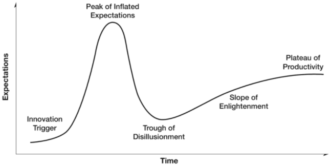

NOTE: figure/graphic rendered as an image from the PDF; its content is not machine-readable text. Caption (if any) follows as the next block.

Fig. 10. Gartner’s hype cycle. *Source* : Adapted from Fenn and Raskino [ 154 ]

**non-fungible tokens** ( **NFTs** ) and Web3 [ 146 ], while major corporations channeled substantial capital into cloud gaming and XR projects [ 147 ].

Despite massive funding volumes and transaction activity, Web3 and NFT games have consistently failed to attract mainstream players. Instead, these games remain dominated by market speculators [ 148 ]. Due to widespread fraud and rug pulls [ 149 ], players exhibit pervasive dis- trust toward those blockchain games [ 150 ]. XR implementations have deficient user experiences [ 151 ]. Moreover, compounded by infrastructure limitations and network environment constraints [ 152 ], cloud gaming services demonstrate subpar quality-of-experience [ 153 ]. Then, most of these metaverse-themed initiatives suffered commercial failures due to a lack of market acceptance.

Gartner’s hype cycle model (see Figure 10 ) is often used to explain the lifecycle of emerging technologies [ 155 ]. Recent research indicates that the sudden rise in popularity followed by the rapid cooldown of metaverse-related technologies and concepts aligns with this model [ 156 ]. From 2020 to 2022, metaverse-related technologies experienced a period of inflated expectations. How- ever, the once-hot concepts of cloud gaming, XR, and Web3, faded from prominence after 2023 due to lack of market acceptance and the emergence of **artificial intelligence** ( **AI** ).

The official launch of OpenAI’s ChatGPT in late 2022 broke user growth records [ 157 ], establishing it as the fastest-growing consumer application, and validating significant market demand for AI tools. Meanwhile, VC pivoted from Web3 investments toward AI, as investments in Web3 games decreased from $ 1.6 billion in Q1 2022 to just $ 221 million by Q1 2024—a drop of over 85% [ 158 ]. Concurrently, VC funding for emerging generative AI notably increased from less than $1 billion in Q1 2022 to $ 9 billion in Q4 2024 [ 159 ]. The resulting capital drought accelerated Web3 gaming’s contraction, culminating in studio layoffs and bankruptcies [ 160 ].

Eventually, the job opportunities these technologies had created vanished as funding dried up. Meanwhile, the tech industry’s shift toward AI has, to some extent, also exacerbated layoffs [ 161 ]. Recent studies have also investigated the AI’s unemployment effects: Qin et al. found that AI increases short-term unemployment [ 162 ], though the impact varies with time and economic con- texts. Wang and Wong project a long-run employment loss of 23% caused by AI [ 163 ], with half of these losses occurring within the first five years of transition. Using a triple-difference analysis on 285,000 U.S. firms, Hosseini and Lichtinger demonstrate that generative AI adoption is associated

Page 15

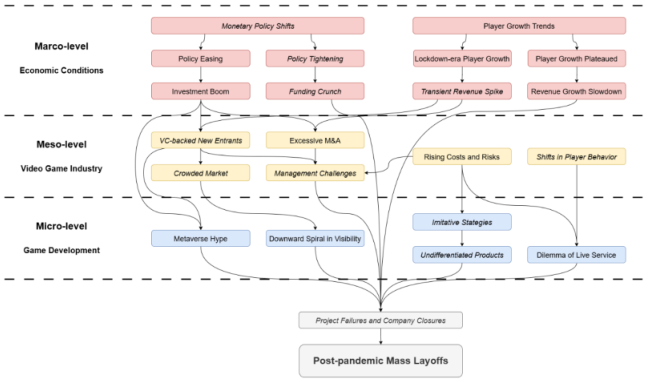

NOTE: figure/graphic rendered as an image from the PDF; its content is not machine-readable text. Caption (if any) follows as the next block.

Fig. 11. Summary of factors organized by the three-level framework. *Notes* : Factors in italics were also present during the Atari Shock.

with a sharp decline in junior employment [ 164 ]. In short, AI poses a potential exacerbation of unemployment.

**8 Results: The Outbreak of Mass Layoffs** The causes of this industry-wide layoff crisis emerging after 2022 are diverse and complex, with layoffs at various companies often resulting from multiple concurrent factors from various levels. From a macroeconomic perspective, the sudden rise in interest rate significantly increased the dif- ficulty for video game companies to secure funding as investors retreated from the risky gaming sector (e.g., References [ 165 , 166 ]), accelerating layoffs among startups relying primarily on equity financing (e.g., References [ 167 –169 ]). Declining revenue and stagnant player growth, alongside pandemic-driven investment boom, led to market saturation and fierce competition. To mitigate risks from rising costs and fierce competition, major gaming corporations adopted conservative and imitative strategies. While established intellectual property (IP)-backed products leveraged existing fanbases, imitative products without an IP faced significantly greater challenges. Players grew increasingly weary of plentiful clones, causing many such games to fail commercially and leading the developers to implement mass layoffs or studio closures (e.g., References [ 170 –172 ]). Meanwhile, AAA studios attempting to pivot from traditional single-player models to GaaS have consistently failed due to a lack of core live service skills: user analytics, in-game event manage- ment, and virtual economy design (e.g., References [ 173 –175 ]).

Furthermore, excessive mergers and acquisitions created significant management challenges, including frequent shifts in parent company strategy and ineffective control of subsidiaries, which also contributed to numerous project failures (e.g., References [ 170 , 176 , 177 ]). VC-backed small and medium-sized studios demonstrated weaker risk resilience due to limited development capability and expertise, usually releasing low-quality games that met commercial failure (e.g., References [ 178 –180 ]). Simultaneously, many metaverse-focused video game companies or internal divisions of major corporations, born of abundant investments during COVID, faced substantial layoffs and

Page 16

closures due to poor market acceptance (e.g., References [ 181 –183 ]). Finally, AI emerged as the latest accelerant of this layoff wave, as widespread adoption negatively impacted programming and art positions, with reports ironically suggesting game developers being replaced by the very AI tools they created [ 184 ].

Ultimately, this triggered a supply-side layoff crisis across the global VGI: Job losses surpassed 10,500 in 2023, surged to 14,600 in 2024, and added 4,000 more by July 2025—with the U.S. consis- tently suffering the deepest cuts throughout 2023–2025 [ 3 ]. In U.S., where the at-will employment doctrine prevails and dismissal protections are weak [ 185 ], major publicly listed gaming compa- nies implemented large-scale workforce reductions (e.g., References [ 186 –188 ]), with some cutting thousands of positions, alongside the cancellation of numerous game projects (e.g., References [ 171 , 189 , 190 ]). Similarly, numerous multinational gaming corporations have implemented either job cuts or full closures of their U.S.-based development studios (e.g., References [ 172 , 191 , 192 ]). Concurrently, layoffs and shutdowns among small-to-medium-sized U.S. video game companies became increasingly frequent (e.g., References [ 193 –195 ]).

Notably, the overall impact on the VGI appears less severe than during the Atari era. Unlike the Atari Shock, which devastated consumer demand, the current layoffs have primarily affected the industry’s supply side while leaving demand relatively stable. This resilience stems from two major factors: globalization and diversification.

**9.1 Globalization** Historically, the global VGI expanded from its initial dominance by North America and Japan to include Western Europe, followed by South Korea, Eastern Europe, and eventually China, which

Page 17

leveraged its vast population and mobile internet uptake to become the largest market. This growth was driven by broader global capitalism and industry globalization in the early 21st century [ 199 ]. Market instability in the West also drove firms to reduce costs through structural and geographic expansion [ 32 ]. These factors accelerated the globalization of production networks and spurred an explosion in the worldwide player base, transforming gaming into a global phenomenon.

Unlike the early 1980s when players could only buy games from local developers and publishers at physical stores, online distribution platforms now make games from around the world accessible to every player [ 200 ]. This worldwide accessibility guarantees that even when production issues, like oversupply or deteriorating quality, impact one region, gamers can still buy games developed in regions that are less affected. Thus, while the current layoff crisis has hit North America hardest [ 4 ], Europe experienced a less severe investment bubble during the 2020–2022 boom, with coun- tries like Germany less affected by production issues due to fewer mergers and stronger dismissal protections [ 201 ]. Similarly, Japan, where mergers were minimal and which maintains a tradition of lifetime employment [ 202 ], also experienced relatively limited layoffs. In reality, games from Europe and Japan, such as *Baldur’s Gate 3, Helldivers 2, The Legend of Zelda: Tears of the Kingdom* , and *Palworld* , have achieved commercial success in the video game market after 2023.

#### **9.2 Diversification**

The diversification of gaming platforms and business models has significantly bolstered the industry’s ability to withstand disruptions. Unlike the Atari era, when players were confined to arcade and home console games, today’s gamers have a variety of options across mobile devices, PCs, and consoles [ 203 ]. Mobile platforms offer a wide range of experiences, from full-fledged apps to instant-play mini-games [ 204 ]. This variety ensures that even if game production and quality one segment of the industry are negatively impacted, players can easily shift their attention to other platforms.

As previously discussed, the live service model has also provided the VGI with stable cash flows and now constitutes a significant portion of industry revenue. This represents another form of diversification in revenue channels. Moreover, it is noteworthy that regions like China and Japan, which have a strong presence of mobile and live service game developers, have been less impacted by the recent wave of layoffs compared with regions like North America and Europe, which are dominated by the traditional premium business model. This resilience can be partly attributed to the advantages of diversification in releasing platforms and business models, which mitigates risks and ensures stability amid industry fluctuations.

**10 Conclusion** The mass layoff crisis that has gripped the U.S. VGI since 2023 is a multifaceted phenomenon rooted in interconnected economic shifts, industry-specific vulnerabilities, and challenges in game devel- opment. This crisis, while distinct in its contemporary context, echoes the structural fragilities of the Atari Shock in 1983, particularly in its exposure to market oversaturation, product homogene- ity, and the shifts of consumer habits. However, the modern industry’s resilience—shaped by glob- alization and platform diversification—has prevented a collapse of the scale witnessed in the 1980s.

At its core, the 2023–2025 crisis emerged from a confluence of factors: macroeconomic tightening—marked by rising interest rates and liquidity contraction—that reversed the pandemic- era investment boom; industry-wide pressures, including inflated development costs and manage- rial inefficiencies; and game production challenges, such as failed transitions to live-service mod- els, overreliance on imitative design, and the collapse of metaverse-related projects due to market rejection. Collectively, these factors triggered a supply-side crisis, with layoffs cascading across large corporations, mid-sized studios, and VC-backed startups alike.

Page 18

Comparisons with the Atari Shock reveal parallels: both crises were characterized by crowded market caused by the rising number of new entrants, imitative strategy that leads to homoge- nized products, and shifts in player behaviors. Yet critical differences define the modern landscape. Unlike the Atari era’s near-total demand destruction, today’s industry demonstrates remarkable shock absorption through two adaptations: First, globalized production networks mitigate re- gional instability, as evidenced by limited layoffs in regions with robust employment protections. Second, diversified revenue streams—particularly mobile gaming and live service models—create counter-cyclical stability that 1980s console-dependent markets lacked. These structural buffers transformed the crisis into a supply-side correction rather than systemic collapse.

For the VGI, sustainable recovery requires the implementation of multifaceted strategies. From a game development perspective, studios should prioritize transcending imitation-driven devel- opment by focusing on differentiation. Developers can also consider controlling team expansion speed and development cycle length, which can effectively reduce management complexity for both companies and projects—as demonstrated by recent successes like *Clair Obscur: Expedition 33* [ 205 ]. In sum, the current crisis serves as a critical reminder that the VGI’s long-term sustainability depends on learning from history while adapting to new realities. By internalizing historical par- allels while leveraging contemporary advantages, I hope that the VGI can transform vulnerability into resilience.

#### **Data Availability Statement**

Data sharing is not applicable to this article as no new data were created or analyzed in this study.

#### **Declaration of Conflicting Interests**

The author is employed by a video game company. However, this study was conducted as an independent academic project without organizational involvement. All data are sourced from publicly available repositories cited in references. The author confirms no financial interests or personal relationships that could influence the research outcomes.

#### **Acknowledgements**

The opinions, findings, and conclusion or recommendations expressed in the article are those of the author.

#### **References**

[1] N. Huntemann and B. Aslinger. 2013. Gaming globally: production, play, and place. *Choice Reviews Online* 51, 01

(2013), 51-0099-51–0099. DOI: 10.5860/CHOICE.51-0099 [2] R. B. Robinson, J. B. Vornhagen, G. Freeman, B. Keogh, R. L. Mandryk, and B. Sinclair. 2024. The impact of mass

game industry layoffs on the CHI PLAY community. In *CHI-PLAY Companion 2024 - Companion Proceedings of the Annual Symposium on Computer–Human Interaction in Play* , Association for Computing Machinery, Inc, 475–477. DOI: 10.1145/3665463.3678861 [3] N. Carpenter. 2025. Data points to slowing layoffs, but doesn’t capture true harm to game industry. *Game Devel-*

*oper* , Retrieved from https://w w w.gamedeveloper.com/business/industry- layoffs- are- seemingly- slowing- but- thedamage- has- already- been- done . Accessed 23-8-2025. [4] S. McEvoy. 2025. Over 50% of games industry layoffs have taken place in California. *GamesIndustry.Biz* , Retrieved

from https://w w w.gamesindustr y.biz/50- of- games- industry- layoffs- have- taken- place- in- california . Accessed 16- 10-2025. [5] B. Elderkin. 2025. GDC 2025 State of the Game Industry: Devs Weigh in on Layoffs, AI, and More. *Game Devel-*

*opers Conference* , Retrieved from https://gdconf.com/news/gdc- 2025- state- game- industry- devs- weigh- layoffs- aiand-more . Accessed 24-2-2025. [6] F. Noor. 2025. 2025 - Game Industry Layoffs - Obsidian Publish. Retrieved from https://publish.obsidian.md/vg-

layoffs/Archive/2025 . Accessed 9-3-2025.

[7] R. Thubron. 2022. China grants its first video game license since July, *Techspot* , Retrieved from https://w w w.techspot.

com/news/94134- china- grants- first- video- game- license- since- july.html . Accessed 9-3-2025. [8] B. Keogh. 2023. *The Videogame Industry Does Not Exist, The Videogame Industry Does Not Exist* . The MIT Press.

DOI: 10.7551/mitpress/14513.001.0001 [9] A. C. Cote and B. C. Harris. 2021. ‘Weekends became something other people did’: Understanding and intervening

in the habitus of video game crunch. *Convergence* 27, 1 (2021), 161–176. DOI: 10.1177/1354856520913865 [10] S. Kline, N. Dyer-Witheford, and G. De Peuter. 2003. *Digital Play: The Interaction of Technology, Culture, and Mar-*

*keting* . McGill-Queen’s University Press. [11] Y. Aoyama and H. Izushi. 2013. Innovation, industry evolution and cross-sectoral skill transfer in the video game

industr y: a three-countr y study. *Handbook of Industry Studies and Economic Geography* , Edward Elgar Publishing, 152–170. DOI: 10.4337/9781782549000.00012 [12] C. Severance. 2013. Gordon Bell: Building blocks of computing. *Computer* 46, 6 (2013), 6–7. DOI: 10.1109/MC.2013.207 [13] A. Marsh. 2024. Past forward: Farewell, my animatronic friends. *IEEE Spectrum* 61, 12 (2024), 72–72. DOI: 10.1109/

MSPEC.2024.10779336 [14] E. Goh, O. Al-Tabbaa, and Z. Khan. 2023. Unravelling the complexity of the Video Game Industry: An integrative

framework and future research directions. *Telematics and Informatics Reports* 12 (2023), 100100. DOI: 10.1016/j.teler. 2023.100100 [15] J. Fleury. 2023. From Superman to Swordquest: Atari and early video game labor exploitation. *American Journal of*

*Economics and Sociology* . DOI: 10.1111/ajes.12551 [16] M. Ernkvist. 2008. Down many times, but still playing the game: Creative destruction and industry crashes in the

early video game industry 1971-1986. In *History of Insolvency and Bankruptcy: From an International Perspective* , K. Cratzer and D. Stiefel (Eds.). Södertörns Academic Studies. 161–191. http://w w w.diva-portal.org/smash/get/diva2: 213024/fulltext01.pdf [17] T. S. Perry. 1984. Consumer electronics: New audio and video developments await their true test in the marketplace;

software support may make the difference. *IEEE Spectrum* 21, 1 (1984), 78–81. DOI: 10.1109/MSPEC.1984.6370146 [18] S. Duran-Nebreda, M. J. O’Brien, R. A. Bentley, and S. Valverde. 2022. Dilution of expertise in the rise and fall

of collective innovation. *Humanities and Social Sciences Communications* 9, 1 (2022), 365. DOI: 10.1057/s41599-022- 01380-5 [19] N. Oxford. 2012. Ten facts about the great video game crash of ’83. *IGN* , Retrieved from https://w w w.ign.com/articles/

2011/09/21/ten- facts- about- the- great- video- game- crash- of- 83 . Accessed 9-2-2025. [20] R. Carter and H. Auken Van. 2006. Small Firm Bankruptcy. *Journal of Small Business Management* 44, 4 (2006), 493–

512. DOI: 10.1111/j.1540-627X.2006.00187.x [21] M. E. Terrones, M. A. Kose, and N. Sugawara. 2020. *Global Recessions, SSRN Electronic Journal* , World Bank, Wash-

ington, DC. DOI: 10.1596/1813- 9450- 9172 [22] R. Guins. 2009. Concrete and Clay: The Life and Afterlife of *E.T. The Extra-Terrestrial* for the Atari 2600. *Design and*

*Culture* 1, 3 (2009), 345–364. DOI: 10.1080/17547075.2009.11643295 [23] List of all Atari 2600 games. 2025. *MobyGames* , Retrieved from https://w w w.mobygames.com/platform/atari-2600/ .

Accessed 10-3-2025. [24] C. A. Kocurek. 2015. *Coin-Operated Americans* University of Minnesota Press. DOI: 10.5749/minnesota/

9780816691821.001.0001 [25] T. Wada. 2019. The core rigidity of Japanese home video game companies, *Annals of Business Administrative Science*

18, 5 (2019), 195–208. DOI: 10.7880/abas.0190921a [26] Y. Nakamura. 2019. Peak Video Game? Top Analyst Sees Industry Slumping in 2019. *Bloomberg* , Re-

trieved from https://w w w.bloomberg.com/news/articles/2019- 01- 23/peak- video- game- top- analyst- sees- industryslumping- in- 2019 . Accessed 11-7-2025. [27] M. Buijsman. 2025. Global games market report & forecast Q1 2025 update. *Newzoo* , Retrieved from https://newzoo.

com/resources/blog/global- games- market- update- q1- 2025 . Accessed 24-8-2025. [28] B. Loguidice and M. Barton. 2014. *Vintage Game Consoles* , Routledge. DOI: 10.4324/9780203728314 [29] H. Ozalp. 2024. Heterogeneous development paths to growth and innovation : the evolution of the video game

industry across four hubs. *SSRN Electronic Journal* . DOI: 10.2139/ssrn.4816101 [30] Valve. 2024. Welcome to Steam, Retrieved from https://store.steampowered.com/ . Accessed 26-11-2024. [31] U. Sandqvist. 2015. The games they are a changin’ : New business models and transformation within the video game

industry. *Humanities and Social Sciences Latvia* 23, 2 (2015), 4–20 [32] A. Kerr. 2017. *Global Games* , Routledge, New York: Routledge, 2017. DOI: 10.4324/9780203704028 [33] C. G. Pickvance. 2001. Four varieties of comparative analysis. *Journal of Housing and the Built Environment* 16, 1

(2001), 7–28. DOI: 10.1023/A:1011533211521

[34] M. Wright, A. Lockett, S. Pruthi, S. Manigart, H. Sapienza, P. Desbrieres, and U. Hommel. 2004. Venture capital

investors, capital markets, valuation and information: US, Europe and Asia. *Journal of International Entrepreneurship* 2, 4 (2004), 305–326. DOI: 10.1007/s10843- 004- 0131- 0 [35] A. Rebucci, J. S. Hartley, and D. Jiménez. 2022. An event study of COVID-19 Central Bank Quantitative Easing in

Advanced and Emerging Economies. *Essays in Honor of M. Hashem Pesaran: Prediction and Macro Modeling* , Emerald Publishing Limited, 291–322. DOI: 10.1108/S0731-90532021000043A014 [36] G. Boehl, G. Goy, and F. Strobel. 2024. A structural investigation of quantitative easing. *Review of Economics and*

*Statistics* 106, 4 (2024), 1028–1044. DOI: 10.1162/rest _ a _ 01205 [37] A. Boldi, A. Rapp, and M. Tirassa. 2024. Playing during a crisis: The impact of commercial video games on the

reconfiguration of people’s life during the COVID-19 pandemic. *Human–Computer Interaction* 39, 5–6 (2024), 338– 379. DOI: 10.1080/07370024.2022.2050725 [38] SteamDB. 2012. SteamDB, *SteamDB* , Retrieved from https://steamdb.info/ . Accessed 26-11-2024. [39] R. H. Clarida, B. Duygan-Bump, and C. Scotti. 2021. The COVID-19 Crisis and the federal reserve’s policy response.

*Finance and Economics Discussion Series* 2021.0, 34 (2021), 1–23. DOI: 10.17016/feds.2021.035 [40] A. Farough and M. Futter. 2024. The game industry’s cataclysmic layoffs: where do we go from here? *Games: Research*

*and Practice* 2, 1 (2024), 1–3. DOI: 10.1145/3651280 [41] V. Glass and T. Tardiff. 2024. The federal trade commission’s antitrust lawsuit against the proposed mi-

crosoft/activision merger: Déjà vu with a surprise ending. *The Antitrust Bulletin* 69, 2–4 (2024), 79–89. DOI: 10.1177/ 0003603X241285050 [42] B. Sinclair. 2021. EA acquires Glu Mobile in $2.1 billion deal. *GamesIndustry.Biz* , Retrieved from https://w w w.

gamesindustry.biz/ea- acquires- glu- mobile- in- usd2- 1- billion- deal . Accessed 24-2-2025. [43] D. Takahashi. 2021. Embracer Group acquires Borderlands maker Gearbox Entertainment for $1.3 billion. *Ven-*

*tureBeat* , Retrieved from https://venturebeat.com/games/embracer-group-acquires-borderlands-maker-gearboxentertainment- for- 1- 3- billion/ . Accessed 24-2-2025. [44] B. R. Kumar. 2024. Case 58 Take-Two interactive software Inc. *Rising Stars: Integrative Case Studies on the 100 Fastest-*

*Growing Companies* , Springer International Publishing, 437–442. DOI: 10.1007/978- 3- 031- 50032- 9 _ 58 [45] E. Pales. 2022. Microsoft and activision-blizzard: examining the largest tech acquisition of all time. *Berkeley Journal*

*of Entertainment and Sports Law* 12, 17 (2022). DOI: 10.2139/ssrn.4106912 [46] Y. Gao, Y. Li, and G. Wu. 2022. The impact of the acquisition of BUNGIE on SONY. In *2022 2nd International Conference*

*on Economic Development and Business Culture (ICEDBC 2022)* , Atlantis Press, 527–533. DOI: 10.2991/978- 94- 6463- 036-7 _ 78 [47] A. Orr. 2022. Mobile games deals reached $15.5 billion in 2021, says Drake Star. *PocketGamer.Biz* , Retrieved from

https://w w w.pocketgamer.biz/mobile- games- deals- reached- 155- billion- in- 2021- says- drake- star/ . Accessed 26-2- 2025. [48] A. Astle. 2024. Q1 2024 saw $2.4 billion in games industry investments, while M&As are up for the first time since

2022. *PocketGamer.Biz* , Retrieved from https://w w w.pocketgamer.biz/q1- 2024- saw- 24- billion- in- games- industryinvestments- while- mandas- are- up- for- the- first- time- since- 2022/ . Accessed 26-2-2025. [49] Federal Reserve Bank of St. Louis. 2025. Federal Funds Effective Rate. *Federal Reserve Economic Data* , Retrieved from

https://fred.stlouisfed.org/series/fedfunds . Accessed 9-3-2025. [50] V. Sergeevih. 2025. Global Gaming Deals Report 2024. *InvestGame* , Retrieved from https://investgame.net/news/

global- gaming- deals- report- 2024/ . Accessed 9-3-2025. [51] J. Kasurinen, M. Palacin-Silva, and E. Vanhala. 2017. What Concerns Game Developers? A Study on Game Devel-

opment Processes, Sustainability and Metrics. *2017 IEEE/ACM 8th Workshop on Emerging Trends in Software Metrics (WETSoM)* . IEEE, 15–21. DOI: 10.1109/WETSoM.2017.3 [52] S. Pilon and D.-G. Tremblay. 2013. The geography of clusters: the case of the video games clusters in montreal and

in los angeles. *Urban Studies Research* (2013), 1–9. DOI: 10.1155/2013/957630 [53] L. Wang, S. Wang, and J. Zhang. 2013. Venture capital backing and overvaluation: evidence from the high-tech

bubble. *Financial Review* 48, 2 (2013), 283–310. DOI: 10.1111/fire.12004 [54] E. Appelbaum and R. Batt. 2014. *Private Equity at Work: When Wall Street Manages Main Street* . Russell Sage Foun-

dation. [55] Federal Reserve Bank of St. Louis. 2025. Software development job postings on indeed in the United States. *Federal Re-*

*serve Economic Data* , Retrieved from https://fred.stlouisfed.org/series/IHLIDXUSTPSOFTDEVE . Accessed 9-3-2025. [56] L. M. S. Tejero, R. R. Seva, and V. F. F. Fadrilan-Camacho. 2021. Factors associated with work-life balance and produc-

tivity before and during work from home. *Journal of Occupational & Environmental Medicine* 63, 12 (2021), 1065–1072. DOI: 10.1097/JOM.0000000000002377 [57] N. Barbour. 2021. Global video game content revenue on course to cross $200B in 2022. *S&P Global* , Retrieved from

https://w w w.spglobal.com/market- intelligence/en/news- insights/research/global- video- game- content- revenueon- course- to- cross- 200b- in- 2022 . Accessed 11-7-2025.

[58] M. Tian. 2024. Impact of the federal reserve interest rate hikes on the U.S. Dollar exchange rate. *Advances in Eco-*

*nomics, Management and Political Sciences* 78, 1 (2024), 67–72. DOI: 10.54254/2754-1169/78/20241636 [59] M. Ji, X. Yang, and C. Liu. 2022. Exploring the motivation and impact of the fed’s rate hike and tapering. *Journal of*

*Economics, Finance and Accounting Studies* 4, 2 (2022), 344–349. DOI: 10.32996/jefas.2022.4.2.28 [60] C. D’Anastasio. 2023. Video Games’ Post-Covid Hangover Triggers Exodus by VC Investors. *Bloomberg* , Re-

trieved from https://w w w.bloomberg.com/news/articles/2023- 10- 05/video- games- post- covid- hangover- triggersexodus- by- vc- investors . Accessed 29-7-2025. [61] S. McEvoy. 2024. Newzoo: Global games market expected to grow to $187bn in 2024. *GameIndustry.Biz* , Re-

trieved from https://w w w.gamesindustr y.biz/newzoo- global- games- market- expected- to- grow- to- 187bn- in- 2024 . Accessed 24-2-2025. [62] T. Wijman. 2023. New free report: Explore the global games market in 2023. *Newzoo* , Retrieved from https://newzoo.

com/resources/blog/explore- the- global- games- market- in- 2023 . Accessed 24-8-2025. [63] T. Wijman. 2021. The games market’s bright future: Player numbers will soar past 3 billion towards 2024 as yearly

revenues exceed $200 Billion. *Newzoo* , Retrieved from https://newzoo.com/resources/blog/the- games- marketsbright- future- player- numbers- will- soar- past- 3- billion- towards- 2024- as- yearly- revenues- exceed- 200- billion . Ac- cessed 26-8-2025. [64] D. Winseck. 2011. The political economies of media and the transformation of the global media industries. *The*

*Political Economies of Media* , Bloomsbury Publishing Plc, 3–48. DOI: 10.5040/9781849664264.0008 [65] N. H. Miller, G. Sheu, and M. C. Weinberg. 2021. Oligopolistic price leadership and mergers: The United States beer

industry. *American Economic Review* 111, 10 (2021), 3123–3159. DOI: 10.1257/aer.20190913 [66] J. Willner and S. Grönblom. 2021. Quality provision under conditions of oligopoly. *Journal of Economics* 132, 2 (2021),

103–131. DOI: 10.1007/s00712- 020- 00714- 8 [67] M. Peneder and M. Woerter. 2014. Competition, R&D and innovation: Testing the inverted-U in a simultaneous

system. *Journal of Evolutionary Economics* 24, 3 (2014), 653–687. DOI: 10.1007/s00191- 013- 0310- z [68] W. Yin-Poole, 2025. The Outer Worlds 2 Is Microsoft’s First Confirmed $80 Game, IGN, Retrieved from https://w w w.

ign.com/articles/the- outer- worlds- 2- is- microsofts- first- confirmed- 80- game . Accessed 28-7-2025. [69] V. Blake. 2021. Battlefield 2042 is now one of Steam’s most poorly reviewed games ever. *GamesRadar* +. Re-

trieved from https://w w w.gamesradar.com/battlefield- 2042- is- now- one- of- steams- most- poorly-reviewed-gamesever/ . Accessed 1-9-2025. [70] S. Parijat. 2023. Redfall’s review scores are “significantly” lower than what microsoft expected. *Gaming-*

*Bolt* , Retrieved from https://gamingbolt.com/redfalls-review-scores-are-significantly-lower-than-what-microsoftexpected . Accessed 1-9-2025. [71] A. Hopley. 2025. Civilization VII Early Access opens to Mostly Negative Steam reviews. *GameReactor* , Retrieved from

https://w w w.gamereactor.eu/civilization- vii- early- access- opens- to- mostly- negative- steam- reviews-1493163/ . Accessed 2-9-2025. [72] J. O. Fiet. 1995. Risk avoidance strategies in venture capital markets. *Journal of Management Studies* 32, 4 (1995),

551–574. DOI: 10.1111/j.1467-6486.1995.tb00788.x [73] M. Schmalz, A. Finn, and H. Taylor. 2014. Risk management in video game development projects. In *2014 47th Hawaii*

*International Conference on System Sciences* . IEEE, 4325–4334. DOI: 10.1109/HICSS.2014.534 [74] E. Bailey and K. Miyata, 2019. Improving video game project scope decisions with data: An analysis of achievements

and game completion rates. *Entertainment Computing* . 31. DOI: 10.1016/j.entcom.2019.100299 [75] D. Kaimann, N. Stroh-Maraun, and J. Cox. 2018. A duration model analysis of consumer preferences and determi-

nants of video game consumption. *Journal of Consumer Behaviour* 17, 3 (2018), 290–301. DOI: 10.1002/cb.1711 [76] S. Casper and C. Storz. 2017. Bounded careers in creative industries: Surprising patterns in video games. *Industry*

*and Innovation* 24, 3 (2017), 213–248. DOI: 10.1080/13662716.2016.1224705 [77] D. Rodríguez, M. A. Sicilia, E. García, and R. Harrison. 2012. Empirical findings on team size and productivity in

software development. *Journal of Systems and Software* 85, 3 (2012), 562–570. DOI: 10.1016/j.jss.2011.09.009 [78] F. P. Brooks. 1975. The mythical man-month. *Proceedings of the International Conference on Reliable Software.* ACM

Press, New York, New York, USA, 193. DOI: 10.1145/800027.808439 [79] R. D. Banker and C. F. Kemerer. 1989. Scale economies in new software development. *IEEE Transactions on Software*

*Engineering* 15, 10 (1989), 1199–1205. DOI: 10.1109/TSE.1989.559768 [80] V. Lalsing. 2012. People factors in Agile software development and project management. *International Journal of*

*Software Engineering & Applications* 3, 1 (2012), 117–137. DOI: 10.5121/ijsea.2012.3109 [81] P. C. Pendharkar and J. A. Rodger. 2009. The relationship between software development team size and software

development cost. *Communications of the ACM* 52, 1 (2009), 141–144. DOI: 10.1145/1435417.1435449 [82] T. F. Bresnahan, S. Greenstein, and R. M. Henderson. 2012. Schumpeterian competition and diseconomies of scope.

*The Rate and Direction of Inventive Activity Revisited* , University of Chicago Press, 203–271. DOI: 10.7208/chicago/ 9780226473062.003.0008

[83] C. Comstock, Z. Jiang, and J. Davies. 2011. Economies and diseconomies of scale in software development. *Journal*

*of Software Maintenance and Evolution: Research and Practice* 23, 8 (2011), 533–548. DOI: 10.1002/smr.526 [84] SpriteCell. 2024. How long it takes to develop a video game. *SpriteCell* , Retrieved from https://spritecell.com/bp12-

video- game- development- time/ . Accessed 22-2-2025. [85] P. C. Oguguo. 2024. Innovation and intellectual property use in the global video game industry. *SSRN Electronic*

*Journal* . DOI: 10.2139/ssrn.4816102 [86] N. Carpenter. 2025. Call of duty: Black ops cold war cost $700M to make. *Polygon* , Retrieved from https://w w w.

polygon.com/news/504702/call- of- duty- black- ops- cold- war- development- costs- 700- million . Accessed 8-3-2025. [87] B. Francis. 2024. Why is it so expensive to make games in the United States?, *Game Developer* , Retrieved from https://

w w w.gamedeveloper.com/business/why- is- it- so- expensive- to- make- games- in- the- united- states- . Accessed 18-8- 2025. [88] J. Clement. 2025. Electronic Arts net income 2025. *Statista* , from https://w w w.statista.com/statistics/698262/income-

loss- electronic- arts/ . Accessed 26-8-2025. [89] J. Clement. 2025. Take-two interactive annual net income 2025. *Statista* , Retrieved from https://w w w.statista.com/

statistics/194445/net- income- of- take- two- interactive- since- 2006/ . Accessed 26-8-2025. [90] M. C. Jensen and W. H. Meckling. 1976. Theory of the firm: Managerial behavior, agency costs and ownership

structure. *Journal of Financial Economics* 3, 4 (1976), 305–360. DOI: 10.1016/0304- 405X(76)90026- X [91] V. Kanniainen. 2000. Empire building by corporate managers. *Journal of Economic Dynamics and Control* 24, 1 (2000),

127–142. DOI: 10.1016/S0165- 1889(98)00065- 7 [92] R. Chetty and E. Saez. 2010. Dividend and corporate taxation in an agency model of the firm. *American Economic*

*Journal: Economic Policy* 2, 3 (2010), 1–31. DOI: 10.1257/pol.2.3.1 [93] L. Wang, M. Kunc, and J. Li. 2020. Project portfolio implementation under uncertainty and interdependencies: A

simulation study of behavioural responses. *Journal of the Operational Research Society* 71, 9 (2020), 1426–1436. DOI: 10.1080/01605682.2019.1609890 [94] M. C. Jensen. 1993. The modern industrial revolution, exit, and the failure of internal control systems. *The Journal*

*of Finance* 48, 3 (1993), 831–880. DOI: 10.1111/j.1540-6261.1993.tb04022.x [95] U. Malmendier and G. Tate. 2005. CEO overconfidence and corporate investment. *The Journal of Finance* 60, 6 (2005),

2661–2700. DOI: 10.1111/j.1540-6261.2005.00813.x [96] N. F. Carline, S. C. Linn, and P. K. Yadav. 2009. Operating performance changes associated with corporate mergers

and the role of corporate governance. *Journal of Banking & Finance* 33, 10 (2009), 1829–1841. DOI: 10.1016/j.jbankfin. 2009.03.012 [97] N. Steigenberger. 2017. The challenge of integration: A review of the M&A integration literature. *International*

*Journal of Management Reviews* 19, 4 (2017), 408–431. DOI: 10.1111/ijmr.12099 [98] J. Hilscher and E. Şişli-Ciamarra. 2013. Conflicts of interest on corporate boards: The effect of creditor-directors on

acquisitions. *Journal of Corporate Finance* 19 (2013), 140–158. DOI: 10.1016/j.jcorpfin.2012.10.001 [99] S. Kansal and A. Chandani. 2014. Effective management of change during merger and acquisition. *Procedia Economics*

*and Finance* 11 (2014), 208–217. DOI: 10.1016/S2212- 5671(14)00189- 0 [100] M. Schraeder and D. R. Self. 2003. Enhancing the success of mergers and acquisitions: An organizational culture

perspective. *Management Decision* 41, 5 (2003), 511–522. DOI: 10.1108/00251740310479359 [101] C. Lewis. 2025. Microsoft reportedly doesn’t include lost first-party game sales when calculating Xbox Game

Pass profits, but the subscription service is apparently earning money regardless. *GamesRadar* +, Retrieved from https://w w w.gamesradar.com/games/microsoft-reportedly-doesnt-include-lost-first-party-game-sales-when- calculating- xbox- game- pass- profits- but- the- subscription- service- is- apparently- earning- money- regardless/ . Accessed 28-7-2025. [102] P. Tassi. 2025. Microsoft is reportedly ‘happy with’ avowed sales so far. *Forbes* , Retrieved from https://w w w.forbes.

com/sites/paultassi/2025/02/23/microsoft- is- reportedly- happy- with- avowed- sales- so- far/ . Accessed 28-7-2025. [103] X. Huang and J. Wei. 2012. Genre innovation and modularization in creative industry. *2012 International Symposium*

*on Management of Technology (ISMOT)* . IEEE, 92–96. DOI: 10.1109/ISMOT.2012.6679435 [104] R. Atkinson. 1999. Project management: cost, time and quality, two best guesses and a phenomenon, its time to

accept other success criteria. *International Journal of Project Management* 17, 6 (1999), 337–342. DOI: 10.1016/S0263- 7863(98)00069-6 [105] R. Łabędzki. 2022. A literature review on human capital management in the video game industry. *Kwartalnik Nauk*

*o Przedsiębiorstwie* 65, 3 (2022), 109–122. DOI: 10.33119/KNoP.2022.65.3.7 [106] A. Kainz and J. Pirker. 2023. SteamVis: A tool for collecting and analyzing data of the game distribution plat-

form steam. *IEEE Conference on Computatonal Intelligence and Games, CIG* . IEEE Computer Society. DOI: 10.1109/ CoG57401.2023.10333255

[107] M. Arafat, A. Qusef, and S. Al-Taher. 2019. Steam’s early access model: A study on consumers’ perspective. *2019 IEEE*

*Jordan International Joint Conference on Electrical Engineering and Information Technology (JEEIT)* . IEEE, 336–341. DOI: 10.1109/JEEIT.2019.8717501 [108] L. O. Mendes, L. R. Cunha, and R. S. Mendes. 2022. Popularity of video games and collective memory. *Entropy* 24, 7

(2022), 860. DOI: 10.3390/e24070860 [109] R. K. Merton. 1968. The Matthew effect in science. *Science* 159, 3810 (1968), 56–63. DOI: 10.1126/science.159.3810.56 [110] A. De Luisa, J. Hartman, D. Nabergoj, S. Pahor, M. Rus, B. Stevanoski, J. Demšar, and E. Štrumbelj. 2021. Predicting

the Popularity of Games on Steam, *ArXiv Preprint* . DOI: 10.48550/arXiv.2110.02896 [111] VG Insights. 2022. About video game insights. *VG Insights* , Retrieved from https://vginsights.com/about . Accessed

27-2-2025. [112] Valve. 2023. Visibility on Steam (Steamworks Documentation). *Steamworks* , Retrieved from https://partner.

steamgames.com/doc/marketing/visibility?l=english . Accessed 27-2-2025. [113] T. H. Davenport and J. C. Beck. 2001. The attention economy. *Ubiquity* , 2001, No. May, 1. DOI: 10.1145/376625.376626 [114] L. Ceci. 2025. U.S. time per day on Netflix, TikTok, YouTube 2024. *Statista* , Retrieved from https://w w w.statista.com/

statistics/1359403/us- time- spent- per- day- netflix- tiktok- youtube/ . Accessed 24-8-2025. [115] T. Wijman. 2024. Last looks: Our final 2023 games market estimates and forecasts. *Newzoo* , Retrieved from https:

//newzoo.com/resources/blog/last- looks- the- global- games- market- in- 2023 . Accessed 24-8-2025. [116] J. Carter. 2024. 15 percent of Steam users played 2024’s game releases. *Game Developer* , Retrieved from https://w w w.

gamedeveloper.com/business/15-percent- of- steam- users- played- 2024- s- game- releases . Accessed 23-8-2025. [117] Valve. 2024. Best of steam 2024. *Steam* , Retrieved from https://store.steampowered.com/sale/bestof2024 . Accessed

27-2-2025. [118] K. Kollnig, A. Shuba, M. Van Kleek, R. Binns, and N. Shadbolt. 2022. Goodbye Tracking? Impact of iOS App Tracking

Transparency and Privacy Labels. In *2022 ACM Conference on Fairness, Accountability, and Transparency* , ACM, New York, NY, USA, 508–520. DOI: 10.1145/3531146.3533116 [119] N. Long. 2025. The top grossing mobile games of 2024. *Mobilegamer.Biz* , Retrieved from https://mobilegamer.biz/

the- top- grossing- mobile- games- of- 2024/ . Accessed 9-3-2025. [120] G. A. Wilson. 2014. Community resilience: path dependency, lock-in effects and transitional ruptures. *Journal of*

*Environmental Planning and Management* 57, 1 (2014), 1–26. DOI: 10.1080/09640568.2012.741519 [121] S. Vasiuk. 2024. *Running a Successful Live Service Game* . CRC Press, Boca Raton. DOI: 10.1201/9781003427056 [122] N. Z. Tomić. 2019. Economic model of microtransactions in video games. *Journal of Economic Science Research* , 1, 1

(2019). DOI: 10.30564/jesr.v1i1.439 [123] W. Cai, M. Chen, and V. C. M. Leung. 2014. Toward gaming as a service. *IEEE Internet Computing* 18, 3 (2014), 12–18.

DOI: 10.1109/MIC.2014.22 [124] D. B. Nieborg. 2011. *Triple-A: The Political Economy of the Blockbuster Video Game* . University of Amsterdam. [125] R. L. Breslin. 2023. Microsoft ‘upset’ with Xbox over lack of first-party games. *GamingBible* , Retrieved from https:

//w w w.gamingbible.com/news/microsoft- upset- xbox- first- party- games- 815087- 20230424 . Accessed 11-7-2025. [126] E. Nightingale. 2022. Sony exec Jim Ryan believes live service games will dominate over subscriptions. *Eurogamer* ,

Retrieved from https://w w w.eurogamer.net/sony- exec- jim- ryan- believes- live- service- games- will- dominate- oversubscriptions . Accessed 24-8-2025. [127] J. Zheng. 2022. Sony projects launching 12 live service games by 2025. *GameSpot* , Retrieved from

https://w w w.gamespot.com/articles/sony-projects-launching-12-live-service-games-by-2025/1100-6503924/ . Accessed 28-7-2025. [128] A. Bernevega and A. Gekker. 2022. The industry of landlords: Exploring the assetization of the triple-a game. *Games*

*and Culture* 17, 1 (2022), 47–69. DOI: 10.1177/15554120211014151 [129] L.-E. Dubois and J. Weststar. 2022. Games-as-a-service: Conflicted identities on the new front-line of video game

development. *New Media & Society* 24, 10 (2022), 2332–2353. DOI: 10.1177/1461444821995815 [130] L. M. Sánchez-Adame, G. Monroy-Rodríguez, S. Mendoza, D. Decouchant, and A. P. Mateos-Papis. 2023. Frame-

work for ethically designed microtransactions in the metaverse. *IEEE Access* 11 (2023), 140687–140700. DOI: 10.1109/ ACCESS.2023.3341057 [131] S. Hotho and K. Champion. 2010. We are always after that balance: Managing innovation in the new digital media

industries. *Journal of Technology Management & Innovation* 5, 3 (2010). DOI: 10.4067/S0718-27242010000300003 [132] F. T. Tschang. 2007. Balancing the tensions between rationalization and creativity in the video games industry.

*Organization Science* 18, 6 (2007), 989–1005. DOI: 10.1287/orsc.1070.0299 [133] S. K. Ethiraj, D. Levinthal, and R. R. Roy. 2008. The dual role of modularity: Innovation and imitation. *Management*

*Science* 54. 5 (2008), 939–955. DOI: 10.1287/mnsc.1070.0775 [134] H. E. Posen, J. Lee, and S. Yi. 2013. The power of imperfect imitation. *Strategic Management Journal* 34, 2 (2013),

149–164. DOI: 10.1002/smj.2007

[135] B. Keogh. 2021. The cultural field of video game production in Australia. *Games and Culture* 16, 1 (2021), 116–135.

DOI: 10.1177/1555412019873746 [136] R. E. Caves. 2003. Contracts between art and commerce. *Journal of Economic Perspectives* 17, 2 (2003), 73–83. DOI: 10.

1257/089533003765888430 [137] L. van Roessel and C. Katzenbach. 2020. Navigating the grey area: Game production between inspiration and imita-

tion. *Convergence* 26, 2 (2020), 402–420. DOI: 10.1177/1354856518786593 [138] C. Katzenbach, S. Herweg, and L. Van Roessel. 2016. Copies, clones, and genre building: Discourses on imitation and

innovation in digital games. *International Journal of Communication* 10, 22 (2016). [139] P.-R. Agénor and H. T. Dinh. 2013. *From Imitation to Innovation : Public Policy for Industrial Transformation* , World

Bank, Washington, DC. DOI: 10.1596/17024 [140] C. Livingston. 2021. What Todd Howard has said about Starfield: ‘It’s like Skyrim in space’ with detailed cheese

sandwiches. *PC Gamer* , Retrieved from https://w w w.pcgamer.com/what- todd- howard- has- said- about- starfield- itslike- skyrim- in- space- with- detailed- cheese- sandwiches/ . Accessed 12-7-2025. [141] E. Kain. 2024. ‘XDefiant’ Doesn’t Feel Like A ‘Call Of Duty’ Killer To Me. *Forbes* , Retrieved from https://w w w.forbes.

com/sites/erikkain/2024/04/30/xdefiant- doesnt- feel- like- a- call- of- duty- killer- to- me/ . Accessed 20-7-2025. [142] T. Phillips. 2024. MultiVersus is a Smash Bros. clone that feels like a smartphone game, spoiled by its monetisa-

tion. *Eurogamer* , Retrieved from https://w w w.eurogamer.net/multiversus- is- a- smash- bros- clone- that- feels- like- asmartphone- game- spoiled- by- its- monetisation . Accessed 8-3-2025. [143] P. Tassi. 2024. PS5’s ‘Concord’ Hero Shooter Roasted By Fans As An ‘Overwatch’ Clone. *Forbes* , Re-

trieved from https://w w w.forbes.com/sites/paultassi/2024/05/31/ps5s- concord- hero- shooter- roasted- by- fans- asan- overwatch- clone/ . Accessed 20-7-2025. [144] J. Peddie. 2022. Game Console GPUs. *The History of the GPU - New Developments* Springer International Publishing,

Cham, 187–237. DOI: 10.1007/978- 3- 031- 14047- 1 _ 4 [145] S. Mystakidis. 2022. Metaverse. *Encyclopedia* 2, 1 (2022), 486–497. DOI: 10.3390/encyclopedia2010031 [146] R. Rai. 2022. An overview of Web3 venture capital activity. In *2021, Forbes* , Retrieved from https://w w w.forbes.com/

sites/rahulrai/2022/01/02/an-overview-of-web3-venture-capital-activity-in-2021/ . Accessed 30-7-2025. [147] B. Egliston and M. Carter. 2021. Critical questions for Facebook’s virtual reality: Data, power and the metaverse.

*Internet Policy Review* 10, 4 (2021). DOI: 10.14763/2021.4.1610 [148] B. Egliston. 2024. *Cryptogaming* . Springer Nature Switzerland, Cham. DOI: 10.1007/978- 3- 031- 73446- 5 [149] K. Lin, J. Wu, D. Lin, and Z. Zheng. 2023. A survey on Metaverse: Applications, crimes and governance. In *2023 IEEE*

*International Conference on Metaverse Computing, Networking and Applications (MetaCom)* . IEEE, 541–549. DOI: 10. 1109/MetaCom57706.2023.00097 [150] Y. O’ Connor and K. O’ Reilly. 2025. Is the Metaverse failing? An exploratory study of self-employed artists and their

resistance to NFTs. *Computers in Human Behavior* 170 (2025), 108701. DOI: 10.1016/j.chb.2025.108701 [151] Li Xichen and J. J. Lee. 2024. Failure stories and surprising findings: Learning from when VR did not work. *Immersive*

*Learning Research Network* , J. M., P. D., D. A., P.-R. A., R. J. Bourguet Marie-Luce, and Krüger (Eds.). Springer Nature Switzerland, Cham, 22–36. DOI: 10.1007/978- 3- 031- 47328- 9 _ 2 [152] P. Graff, X. Marchal, T. Cholez, S. Tuffin, B. Mathieu, and O. Festor. 2021. An analysis of cloud gaming platforms

behavior under different network constraints. In *2021 17th International Conference on Network and Service Management (CNSM)* . IEEE, 551–557. DOI: 10.23919/CNSM52442.2021.9615562 [153] H. Iqbal, A. Khalid, and M. Shahzad. 2021. Dissecting cloud gaming performance with DECAF. In *Proceedings of the*

*ACM on Measurement and Analysis of Computing Systems* 5, 3 (2021), 1–27. DOI: 10.1145/3491043 [154] J. Fenn and M. Raskino. 2008. *Mastering the Hype Cycle: How to Choose the Right Innovation at the Right Time* Harvard

Business Review Press. [155] O. Dedehayir and M. Steinert. 2016. The hype cycle model: A review and future directions. *Technological Forecasting*

*and Social Change* 108 (2016), 28–41. DOI: 10.1016/j.techfore.2016.04.005 [156] A. Marshall and C. Bieck. 2024. Metaverse: The post–hype future. *Strategy & Leadership* 52, 2 (2024), 17–21. DOI: 10.

1108/SL- 12- 2023- 0122 [157] K. Hu. 2023. ChatGPT sets record for fastest-growing user base - Analyst note. *Reuters* , Retrieved from https://

w w w.reuters.com/technology/chatgpt- sets- record- fastest- growing- user- base- analyst- note- 2023- 02- 01/ . Accessed 15-7-2025. [158] V. Sergeevih. 2024. Web3 gaming investments in 2020–2024: The highs, the lows, and the future. *InvestGame* , Re-

trieved from https://investgame.net/news/web3- gaming- investments- in- 2020- 2024/ . Accessed 15-7-2025. [159] I. Struta, 2024. GenAI funding on track to set new record in 2024. *S&P Global* , Retrieved from https:

//w w w.spglobal.com/market- intelligence/en/news- insights/articles/2024/10/genai- funding- on- track- to- setnew-record-in-2024-85779779 . Accessed 15-7-2025.

[160] J. Schreier. 2022. Blockchain Game Studio Mythical Games Cuts 10% of Staff. *Bloomberg* , Retrieved from https://w w w.

bloomberg.com/news/articles/2022- 11- 04/blockchain- game- studio- mythical- games- cuts- 10- of- staff. Accessed 22- 7-2025. [161] R. Nieva. 2025. You’re not imagining it: AI is already taking tech jobs. *Forbes* , Retrieved from https://w w w.forbes.

com/sites/richardnieva/2025/07/17/ai- tech- layoffs/ . Accessed 17-10-2025. [162] M. Qin, Y. Wan, J. Dou, and C. W. Su. 2024. Artificial intelligence: Intensifying or mitigating unemployment? *Tech-*

*nology in Society* 79 (2024), 102755. DOI: 10.1016/j.techsoc.2024.102755 [163] P. Wang and T.-N. Wong. 2025. Artificial intelligence and technological unemployment. *SSRN Electronic Journal* .

DOI: 10.2139/ssrn.5278370 [164] G. Lichtinger and S. M. Hosseini Maasoum. 2025. Generative AI as seniority-biased technological change: Evidence

from U.S. résumé and job posting data. *SSRN Electronic Journal* . DOI: 10.2139/ssrn.5425555 [165] Bloomberg News. 2025. NetEase’s Billionaire CEO Ding slashes jobs, games in profit push. *Bloomberg* ,

Retrieved from https://w w w.bloomberg.com/news/articles/2025- 02- 21/netease- s- billionaire- ceo- slashes- jobs- andgames- in- profit- push . Accessed 3-3-2025. [166] J. Carter. 2023. *Report* : Embracer’s doomed $2B deal was with Saudi-backed Sav v y Games. *Game De-*

*veloper* , Retrieved from https://w w w.gamedeveloper.com/business/report- embracer- s- doomed- 2b- deal- was- withsaudi- backed- sav v y-games . Accessed 17-10-2025. [167] A. Chalk. 2025. NetEase pulls funding for another studio: Former Halo Infinite design head says Jar of Sparks is

‘halting work’ while it looks for a new publisher. *PC Gamer* , Retrieved from https://w w w.pcgamer.com/gamingindustry/netease- pulls- funding- for- another- studio- former- halo- infinite- design- head- says- jar- of- sparks- is- halting- work- while- it- looks- for- a- new- publisher/ . Accessed 19-7-2025. [168] V. P. Kennedy. 2024. Wyrdsong developer Something Wicked reportedly impacted by layoffs. *Eurogamer* , Retrieved

from https://w w w.eurogamer.net/wyrdsong- developer- something- wicked- reportedly- impacted- by- layoffs . Accessed 19-7-2025. [169] J. Carter. 2024. Prytania Media ends Crop Circle Games furlough saga with a studio shutdown. *Game Devel-*

*oper* , Retrieved from https://w w w.gamedeveloper.com/business/prytania-media-ends-crop-circle-games-furloughsaga- with- a- studio- shutdown . Accessed 19-7-2025. [170] K. Bailey. 2024. Firewalk studios officially closing following concord’s disastrous release and subsequent shut-

down. *IGN* , Retrieved from https://w w w.ign.com/articles/firewalk- studios- officially- closing- following- concordsdisastrous-release-and-subsequent-shutdown . Accessed 16-8-2025. [171] V. Blake. 2025. Warner Bros shuttering Monolith Productions, Player First Games, and Warner Bros San Diego.

*GameIndustry.Biz* , Retrieved from https://w w w.gamesindustr y.biz/warner- bros- shuttering- monolith- productionsplayer- first- games- and- warner- bros- san- diego . Accessed 16-8-2025. [172] M. Wales. 2024. Ubisoft shutting studios, laying off 277 employees as it pulls plug on live-service shooter XDe-

fiant. *Eurogamer* , Retrieved from https://w w w.eurogamer.net/ubisoft- shutting- studios- laying- off- 277- employeesas- it- pulls- plug- on- live- service- shooter- xdefiant . Accessed 3-3-2025. [173] P. Tassi. 2023. Arkane Cannot Kill Redfall’s ‘Live’ Plans, Even If It Should. *Bloomberg* , Retrieved from

https://w w w.forbes.com/sites/paultassi/2023/05/05/arkane- cannot- kill- redfalls- live- plans- even- if- it- should/ . Accessed 28-7-2025. [174] M. Cripe. 2024. WB games says it plans to double down on live service despite suicide squad failing to meet ex-

pectations. *IGN* , Retrieved from https://w w w.ign.com/articles/wb- games- says- it- plans- to- double- down- on- liveservice- despite- suicide- squad- failing- to- meet- expectations . Accessed 28-7-2025. [175] J. Batchelor. 2024. Insiders blame Suicide Squad’s failings on changing vision and lack of live service skills. *GamesIn-*

*dustry.Biz* , Retrieved from https://w w w.gamesindustr y.biz/insiders- blame- suicide- squads- failings- on- changingvision- and- lack- of- live- service- skills . Accessed 28-7-2025. [176] S. Parijat. 2023. Redfall’s development reportedly had no involvement from microsoft. *GamingBolt* , Retrieved

from https://gamingbolt.com/redfalls-development-reportedly-had-no-involvement-from-microsoft . Accessed 20- 7-2025. [177] A. Chalk. 2023. After 3 years of ‘hands-off’ management, Microsoft is making Bethesda and ZeniMax report directly

to an Xbox bigwig. *PC Gamer* , Retrieved from https://w w w.pcgamer.com/after- 3- years- of- hands- off- managementmicrosoft- is- making- bethesda- and- zenimax- report- directly- to- an- xbox- bigwig/ . Accessed 20-7-2025. [178] C. Kerr. 2025. Mountaintop Studios shutting down after debut shooter Spectre Divide falls short. *Game Devel-*

*oper* , Retrieved from https://w w w.gamedeveloper.com/business/mountaintop- studios- shutting- down- after- debutshooter-spectre-divide-falls-short . Accessed 20-7-2025. [179] J. Wagner. 2025. Seekers of Skyveil, the MOBA—extraction shooter mashup, is shutting down less than a month

after release: ‘We have no choice but to bring this short journey to an end’. *PC Gamer* , Retrieved from https://w w w.

pcgamer.com/games/moba/seekers- of- skyveil- the- moba- extraction- shooter- mashup- is- shutting- down- lessthan- a- month- after- release- we- have- no- choice- but- to- bring- this- short- journey- to- an- end/ . Accessed 20-7-2025. [180] W. Yin-Poole. 2025. Splitgate 2 Dev 1047 Games Hit by Layoffs Amid Turbulent Launch, Co-Founders Say They

Won’t Take Salaries ‘As We Lock in to Deliver the Next Phase of the Project’. *IGN* , Retrieved from https://w w w. ign.com/articles/splitgate- 2- dev- 1047- games- hit- by- layoffs- amid- turbulent- launch- co- founders- say- they- wont- take- salaries- as- we- lock- in- to- deliver- the- next- phase- of- the- project . Accessed 20-7-2025. [181] A. Chalk. 2024. Lone Echo developer Ready at Dawn has reportedly been closed by Meta. *PC Gamer* ,

Retrieved from https://w w w.pcgamer.com/games/vr/lone- echo- developer- ready- at- dawn- has- reportedly-beenclosed- by- meta/ . Accessed 14-7-2025. [182] J. Novet. 2024. Microsoft confirms mixed reality layoffs, will keep selling HoloLens 2, *CNBC* , Retrieved from https://

w w w.cnbc.com/2024/06/03/microsoft- confirms- mixed- reality- layoffs- will- keep- selling- hololens- 2.html . Accessed 14-7-2025. [183] T. Gerken. 2023. Gamers say goodbye to Google’s Stadia as platform shuts. *BBC* , Retrieved from https://w w w.bbc.

com/news/technology-64293595 . Accessed 9-3-2025. [184] A. Robinson. 2025. Laid off King staff are reportedly being replaced by AI tools they helped build. *Video Games Chron-*

*icle* , from https://w w w.videogameschronicle.com/news/laid- off- king- staff- are- reportedly- being- replaced- by- aitools- they- helped- build/ . Accessed 20-7-2025. [185] K. V. W. Stone. 2007. Revisiting the at-will employment doctrine: imposed terms, implied terms, and the normative

world of the workplace. *Industrial Law Journal* 36, 1 (2007), 84–101. DOI: 10.1093/indlaw/dwl042 [186] R. Valentine. 2024. EA to Lay Off Around 670 Workers, Sunsetting Games, ‘Moving Away From Future Licensed IP’.

*IGN* , Retrieved from https://w w w.ign.com/articles/ea- to- lay- off- around- 670- to- advance- the- way- we- work . Accessed 19-7-2025. [187] B. Sinclair. 2024. Take-Two laying off 5% of staff, *GamesIndustry.Biz* , Retrieved from https://w w w.gamesindustr y.

biz/take- two- laying- off- 5- of- staff. Accessed 28-2-2025. [188] E. Lagatta and P. Davidson. 2024. Microsoft to lay off 1,900 Activision, Xbox workers. *USA Today* . 03B–03B. [189] E. Makuch. 2025. All The Xbox Games Canceled And Studios Closed In Microsoft’s Latest Mass Layoffs.

*GameSpot* , Retrieved from https://w w w.gamespot.com/galler y/all- the- xbox- games- cancelled- and- studios- closedin- microsofts- latest- mass- layoffs/2900- 6726/ . Accessed 19-7-2025. [190] R. Valentine. 2025. EA Cancels Black Panther Game, Closes Cliffhanger Games. *IGN* , Retrieved from https://w w w.

ign.com/articles/ea- cancels- black- panther- game- closes- cliffhanger- games . Accessed 16-8-2025. [191] J. Carter. 2023. Saints Row developer Volition has been shut down. *Game Developer* , Retrieved from https://w w w.

gamedeveloper.com/business/saints- row- developer- volition- has- been- shut- down . Accessed 3-3-2025. [192] D. Bailey. 2023. After disappointing sales and DLC, The Callisto Protocol studio has laid off 32 people. *GamesRadar* +,

Retrieved from https://w w w.gamesradar.com/after- disappointing- sales- and- dlc- the- callisto- protocol- studio- haslaid- off- 32- people/ . Accessed 3-8-2025. [193] J. Carter. 2024. Killer Klowns dev Illfonic ‘realigns’ studio by cutting staff. *Game Developer* , Retrieved from https:

//w w w.gamedeveloper.com/business/killer- klowns- dev- illfonic- layoffs . Accessed 3-8-2025. [194] R. Valentine. 2023. Immortals of Aveum studio hit by steep layoffs amid poor sales. *IGN* , Retrieved from https:

//w w w.ign.com/articles/immortals- of- aveum- studio- hit- by- steep- layoffs- amid- poor-sales . Accessed 3-8-2025. [195] A. Chalk. 2025. Iron Galaxy lays off 66 employees in a ‘last resort’ effort to ‘enable our long term survival’. *PC*

*Gamer* , Retrieved from https://w w w.pcgamer.com/gaming- industry/iron- galaxy- lays- off- 66- employees- in- a- lastresort- effort- to- enable- our- long- term- survival/ . Accessed 3-8-2025. [196] Z. Kachwala. 2025. ‘Battlefield’ maker Electronic Arts to go private in record-setting $55 billion LBO. *Reuters* ,

Retrieved from https://w w w.reuters.com/business/media-telecom/electronic- arts- go- private- 55- billion- deal- withpif- silver- lake- 2025- 09- 29/ . Accessed 17-10-2025. [197] Edwin Evans-Thirlwell. 2025. Unionised EA workers slam billion dollar buyout for risking layoffs to ‘pad

investor pockets’, while senators worry about Saudi Arabia rewriting US history *. Rock Paper Shotgun* , Retrieved from https://w w w.rockpapershotgun.com/unionised- ea- workers- slam- billion- dollar- buyout- for- risking- layoffs- to- pad- investor- pockets- while- senators- worry- about- saudi- arabia- rewriting- us- history . Accessed 17-10- 2025. [198] J. Helliwell, T. Peeters, P. Praet, and P. Reding. 1987. International trade and exchange rates in the late eighties. *The*

*Economic Journal* 97, 387 (1987), 782. DOI: 10.2307/2232956 [199] N. Dyer-Witheford and G. De Peuter. 2009. *Games of Empire: Global Capitalism and Video Games* , University of

Minnesota Press. [200] E. J. Toy, J. V. H. H. Kummaragunta, and J. S. Yoo. 2018. Large-scale cross-country analysis of steam popularity. *2018*

*International Conference on Computational Science and Computational Intelligence (CSCI)* . IEEE, 1054–1058. DOI: 10. 1109/CSCI46756.2018.00205

[201] T. Eger. 2003. Opportunistic termination of employment contracts and legal protection against dismissal in Germany

and the USA. *International Review of Law and Economics* 23, 4 (2003), 381–403. DOI: 10.1016/j.irle.2003.07.003 [202] H. Ono. 2010. Lifetime employment in Japan: Concepts and measurements. *Journal of the Japanese and International*

*Economies* 24, 1 (2010), 1–27. DOI: 10.1016/j.jjie.2009.11.003 [203] C. Feijoo, J.-L. Gómez-Barroso, J.-M. Aguado, and S. Ramos. 2012. Mobile gaming: Industry challenges and policy

implications. *Telecommunications Policy* 36, 3 (2012), 212–221. DOI: 10.1016/j.telpol.2011.12.004 [204] C. Wang, H. Lu, C. Gao, Z. Li, T. Xiong, Y. Deng. 2023. A Unified Framework for Mini-game Testing: Experience

on WeChat. In *Proceedings of the 31st ACM Joint European Software Engineering Conference and Symposium on the Foundations of Software Engineering* , ACM, New York, NY, USA, 1623–1634. DOI: 10.1145/3611643.3613868 [205] A. Chalk. 2025. Hideo Kojima says the Clair Obscur: Expedition 33 development team is his ‘ideal’ size: ‘They only

have like 33 team members and a dog’. *PC Gamer* , Retrieved from https://w w w.pcgamer.com/gaming-industry/ hideo- kojima- says- the- clair- obscur- expedition- 33- development- team- is- his- ideal- size- they- only- have- like- 33- team- members- and- a- dog/ . Accessed 25-8-2025.

Received 22 April 2025; revised 19 October 2025; accepted 30 October 2025